# Covid-19 in Philadelphia

Menghan Zhang

Dec 8th 2020

### Purpose of analysis

Covid-19 still has a serious impact throughout the world. I am planning to explore the cases and death caused by it in Philadelphia, analyzing its trends and give some suggestions on prevention.

### Data description

#### Data come from：Pennsylvania department of health

https://data.pa.gov/Health/COVID-19-Aggregate-Cases-Current-Daily-County-Heal/j72v-r42c

https://data.pa.gov/Health/COVID-19-Aggregate-Death-Data-Current-Daily-County/fbgu-sqgp

#### Data Provided by ：Pennsylvania Department of Health

#### Dataset Owner ：Jere Matthews

#### Date Created：October 8, 2020

#### Data Last Updated：November 22, 2020

### Data access

```r
#Two different data sources imported：
Case <- read.csv ( "COVID-19_Aggregate_Cases_Current_Daily_County_Health.csv", header=TRUE, sep=",")

Death <- read.csv ( "COVID-19_Aggregate_Death_Data_Current_Daily_County_Health.csv", header=TRUE, sep=",")
```

```r
#Inspecting Data Intake
names(Case)
```

```
## [1] "Jurisdiction"                 "Date"
## [3] "New.Cases"                    "X7.day.Average.New.Cases"
## [5] "Cumulative.cases"             "Population..2018."
## [7] "New.Case.Rate"                "X7.Day.Average.New.Case.Rate"
## [9] "Cumulative.Case.Rate"
```

```r
str(Case)
```

```
## 'data.frame':    18088 obs. of  9 variables:
##  $ Jurisdiction                : Factor w/ 68 levels "Adams","Allegheny",..: 1 1 1 1 1 1 1 1 1 1 ...
##  $ Date                        : Factor w/ 266 levels "03/01/2020","03/02/2020",..: 1 2 3 4 5 6 7 8 9 10 ...
##  $ New.Cases                   : int  0 0 0 0 0 0 0 0 0 0 ...
##  $ X7.day.Average.New.Cases    : num  NA NA NA NA NA NA NA 0 0 0 ...
##  $ Cumulative.cases            : int  0 0 0 0 0 0 0 0 0 0 ...
##  $ Population..2018.           : int  102811 102811 102811 102811 102811 102811 102811 102811 102811 102811 ...
##  $ New.Case.Rate               : num  0 0 0 0 0 0 0 0 0 0 ...
##  $ X7.Day.Average.New.Case.Rate: num  NA NA NA NA NA NA NA 0 0 0 ...
##  $ Cumulative.Case.Rate        : num  0 0 0 0 0 0 0 0 0 0 ...
```

Case Data has 9 variables and 18088 cases.

Each case represents the number of people infected with covid-19 in various parts of Pennsylvania each day.

```r
names(Death)
```

```
## [1] "County.Name"                   "Date.of.Death"
## [3] "New.Deaths"                    "X7.day.Average.New.Deaths"
## [5] "Total.Deaths"                  "X2018.Population"
## [7] "New.Deaths.Rate"               "X7.day.Average.New.Death.Rate"
## [9] "Total.Death.Rate"
```

```r
str(Death)
```

```
## 'data.frame':    16864 obs. of  9 variables:
##  $ County.Name                  : Factor w/ 68 levels "Adams","Allegheny",..: 1 1 1 1 1 1 1 1 1 1 ...
##  $ Date.of.Death                : Factor w/ 248 levels "03/18/2020","03/19/2020",..: 1 2 3 4 5 6 7 8 9 10 ...
##  $ New.Deaths                   : int  0 0 0 0 0 0 0 0 0 0 ...
##  $ X7.day.Average.New.Deaths    : num  NA NA NA NA NA NA NA 0 0 0 ...
##  $ Total.Deaths                 : int  0 0 0 0 0 0 0 0 0 0 ...
##  $ X2018.Population             : int  102811 102811 102811 102811 102811 102811 102811 102811 102811 102811 ...
##  $ New.Deaths.Rate              : num  0 0 0 0 0 0 0 0 0 0 ...
##  $ X7.day.Average.New.Death.Rate: num  NA NA NA NA NA NA NA 0 0 0 ...
##  $ Total.Death.Rate             : num  0 0 0 0 0 0 0 0 0 0 ...
```

Each case represents the number of people who die of covid-19 in various parts of Pennsylvania each day.

After getting the information, it is found that some sells is NA .

After viewing the csv source file, it is found that there is no data in this cell, and there is no problem in importing the data.

### Data wrangling

```r
library(dplyr)
```

```r
library(ggplot2)
```

```r
#General data wrangling
#Select variables and observations and sort them by time.
Philadelphia_case <- filter ( Case , Jurisdiction  == "Philadelphia" )
Philadelphia_death <- filter ( Death , County.Name  == "Philadelphia" )
#A spread or gather operation (or equivalent):
Ph_case <- select ( arrange ( Philadelphia_case , Date ) , 1:3 , 5:6 )
Ph_death <- select ( arrange ( Philadelphia_death , Date.of.Death ), 1:3 , 5:6 )
```

```r
#View selection and sorting.
head(Ph_case)
```

```
##   Jurisdiction       Date New.Cases Cumulative.cases Population..2018.
## 1 Philadelphia 03/01/2020         0                0           1584138
## 2 Philadelphia 03/02/2020         0                0           1584138
## 3 Philadelphia 03/03/2020         0                0           1584138
## 4 Philadelphia 03/04/2020         0                0           1584138
## 5 Philadelphia 03/05/2020         0                0           1584138
## 6 Philadelphia 03/06/2020         0                0           1584138
```

```r
head(Ph_death)
```

```
##    County.Name Date.of.Death New.Deaths Total.Deaths X2018.Population
## 1 Philadelphia    03/18/2020          0            0          1584138
## 2 Philadelphia    03/19/2020          0            0          1584138
## 3 Philadelphia    03/20/2020          0            0          1584138
## 4 Philadelphia    03/21/2020          0            0          1584138
## 5 Philadelphia    03/22/2020          0            0          1584138
## 6 Philadelphia    03/23/2020          2            2          1584138
```

The selection of variables and sorting are normal.

```r
#Join operation
names ( Ph_death )[ 2 ] <- "Date"
case_death <- Ph_case %>% full_join ( Ph_death, by = "Date" )
case_death <- select( case_death , 1:4 , 7:8 , 5 , -6 )
```

```r
#Check the merger
head(case_death)
```

```
##   Jurisdiction       Date New.Cases Cumulative.cases New.Deaths
## 1 Philadelphia 03/01/2020         0                0         NA
## 2 Philadelphia 03/02/2020         0                0         NA
## 3 Philadelphia 03/03/2020         0                0         NA
## 4 Philadelphia 03/04/2020         0                0         NA
## 5 Philadelphia 03/05/2020         0                0         NA
## 6 Philadelphia 03/06/2020         0                0         NA
##   Total.Deaths Population..2018.
## 1           NA           1584138
## 2           NA           1584138
## 3           NA           1584138
## 4           NA           1584138
## 5           NA           1584138
## 6           NA           1584138
```

The merger is in good shape.

```r
#Reduction and/or transformation functions:
sum(case_death [,3])
```

```
## [1] 54932
```

```r
max(case_death [,3])
```

```
## [1] 1153
```

```r
case_death$Date[grep(max(case_death [,3]), case_death$New.Cases)]
```

```
## [1] "11/12/2020"
```

The largest number of new cases in a single day is 1153, and the cumulative number of patients is 54932. The largest number of new cases so far is on “11/12/2020”, which shows that the infection is still serious.

```r
sum(case_death [,5], na.rm=TRUE)
```

```
## [1] 1979
```

```r
max(case_death [,5], na.rm=TRUE)
```

```
## [1] 61
```

```r
case_death$Date [grep(max(case_death [,5], na.rm=TRUE), case_death$New.Deaths)]
```

```
## [1] "04/17/2020"
```

The largest number of new deaths in a single day is 61, and the cumulative number of patients is 1979.The largest number of new deaths so far is on “04/17/2020”, which shows that the death of patients has been alleviated.

### Data visualization

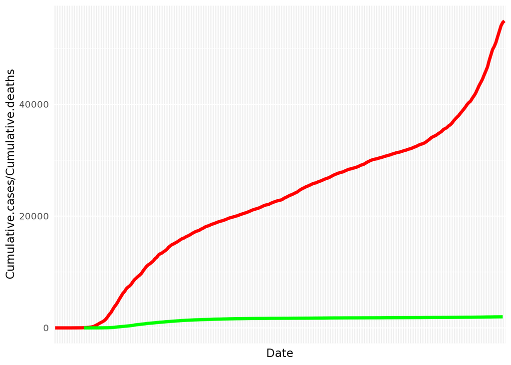

```r
#Line graph of cumulative cases/deaths
ggplot(case_death) +
geom_line(aes(x = case_death[,2], y = case_death[,4]), group = 1, size = 1.5, color="red") +
geom_line(aes(x = case_death[,2], y = case_death[,6]), group = 1, size = 1.5, color="green") +
theme(axis.ticks = element_blank(), axis.text.x = element_blank()) +
labs ( x = "Date" , y = "Cumulative.cases/Cumulative.deaths" )
```

It can be seen from the graph that the cumulative number of cases rose rapidly in the initial stage, slowed down in the intermediate stage, and recently increased rapidly. The cumulative deaths are relatively gentle, with little fluctuations.